# Lab 9 HPC

Author

Michelle Hernandez

```r
library(parallel)
library(microbenchmark)
```

## **Problem 1: Vectorization**

The following functions can be written to be more efficient without using parallel. Write a faster version of each function and show that (1) the outputs are the same as the slow version, and (2) your version is faster.

1. This function generates an `n x k` dataset with all its entries drawn from a Poission distribution with mean `lambda`.

   the given code is saying to draw 4 samples from a pois dist with mean 4 then do this 100 times and bind it to x so you get 100 rows with 4 columns , generating the 4 numbers 100 times

```r
fun1 <- function(n = 100, k = 4, lambda = 4) {
  x <- NULL

  for (i in 1:n){
    x <- rbind(x, rpois(k, lambda))
  }

  return(x)
}
result <- fun1()
#print(result)



fun1alt <- function(n = 100, k = 4, lambda = 4) {
  x <- matrix(rpois(n * k, lambda), nrow = n, ncol = k)
  return(x)
}
resultalt <-fun1alt()
#print(resultalt)
```

Show that `fun1alt` generates a matrix with the same dimensions as `fun1` and that the values inside the two matrices follow similar distributions. Then check the speed of the two functions with the following code:

```r
microbenchmark::microbenchmark(
  fun1(),
  fun1alt()
)
```

```
Unit: microseconds
      expr     min      lq      mean  median       uq      max neval
    fun1() 327.381 483.018 513.31053 494.683 515.4950  995.577   100
 fun1alt()  19.096  21.134  47.53468  22.414  25.1815 2364.961   100
```

```r
dim(result)
```

```
[1] 100   4
```

```r
dim(resultalt)
```

```
[1] 100   4
```

```r
mean(result[1:100,])
```

```
[1] 3.9875
```

```r
mean(resultalt[1:100,])
```

```
[1] 4.165
```

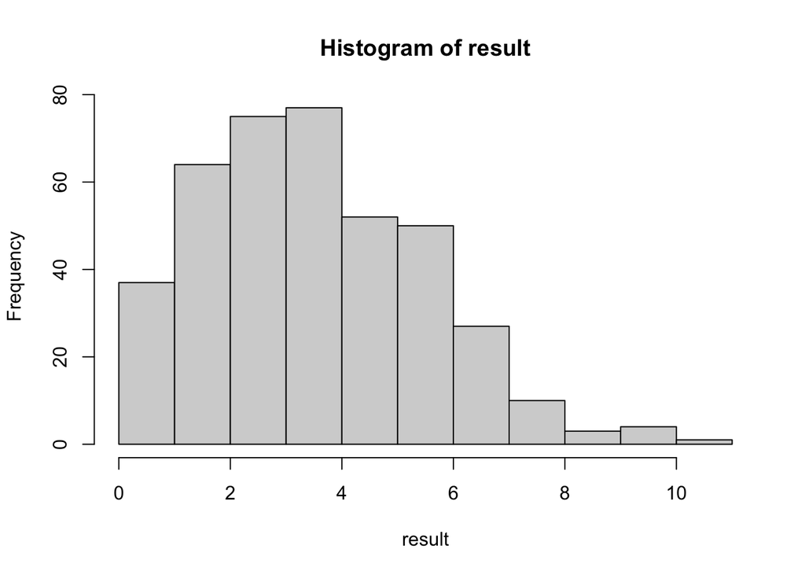

```r
hist(result)
```

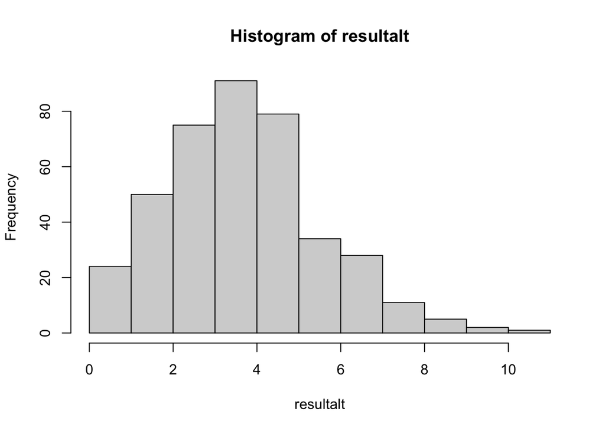

```r
hist(resultalt)
```

2. This function finds the maximum value of each column of a matrix (hint: check out the `max.col()` function).

```r
library(matrixStats)
set.seed(1234)
x <- matrix(rnorm(1e4), nrow=10)

# Find each column's max value
fun2 <- function(x) {
  apply(x, 2, max)
}
result2 <- fun2(x)

fun2alt <- function(x) {
  max_val <- colMaxs(x)
}
result2alt <- fun2alt(x)
```

```r
microbenchmark::microbenchmark(
  fun2(x),
  fun2alt(x)
)
```

```
Unit: microseconds
       expr      min        lq       mean   median       uq      max neval
    fun2(x) 1055.641 1142.3440 1325.37159 1206.758 1371.071 3360.772   100
 fun2alt(x)   41.507   44.1185   61.71131   46.432   53.839 1234.219   100
```

```r
dim(result2)
```

[output not shown]

```r
dim(result2alt)
```

[output not shown]

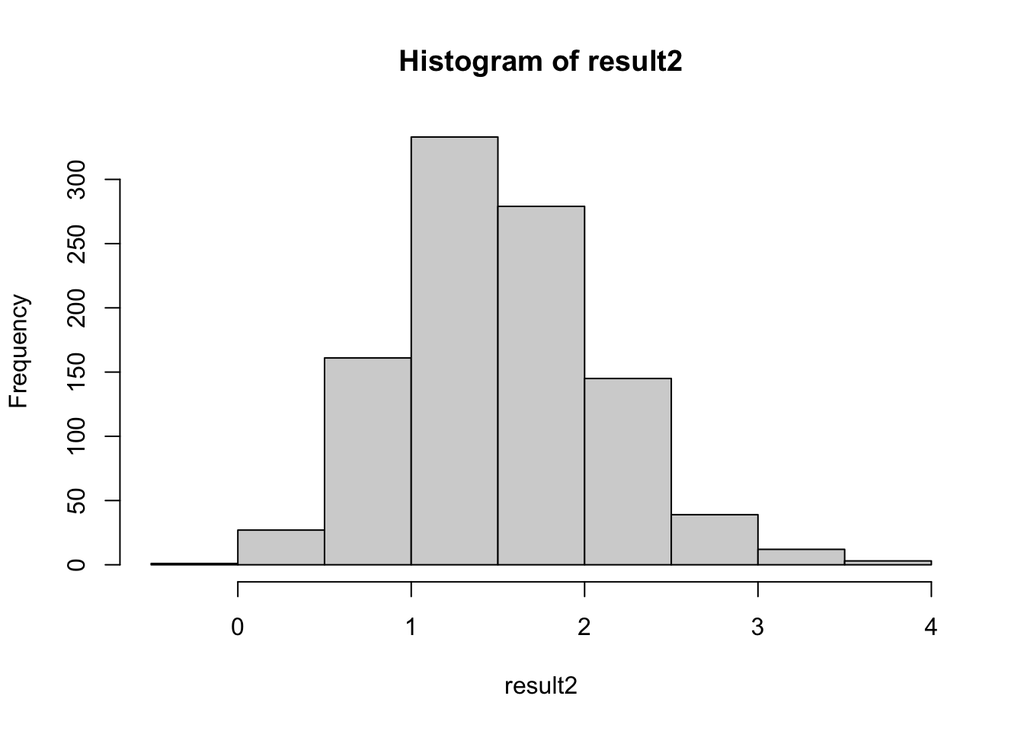

```r
hist(result2)
```

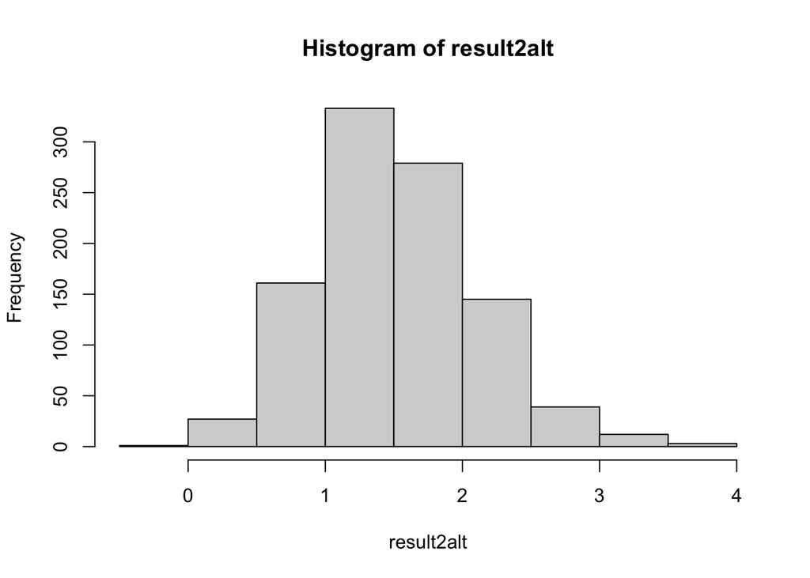

```r
hist(result2alt)
```

## **Problem 3: Parallelization**

We will now turn our attention to the statistical concept of [bootstrapping](https://en.wikipedia.org/wiki/Bootstrapping_%28statistics%29). Among its many uses, non-parametric bootstrapping allows us to obtain confidence intervals for parameter estimates without relying on parametric assumptions. Don’t worry if these concepts are unfamiliar, we only care about the computation methods in this lab, not the statistics.

The main assumption is that we can approximate the results of many repeated experiments by resampling observations from our original dataset, which reflects the population.

1. This function implements a serial version of the bootstrap. Edit this function to parallelize the `lapply` loop, using whichever method you prefer. Rather than specifying the number of cores to use, use the number given by the `ncpus` argument, so that we can test it with different numbers of cores later.

```r
my_boot <- function(dat, stat, R, ncpus = 1L) {


  n <- nrow(dat)
  idx <- matrix(sample.int(n, n*R, TRUE), nrow=n, ncol=R)

  ans <- mclapply(1:1L,
                  function(i) {
    stat(dat[idx[,i], , drop=FALSE])
  }, mc.cores=1L)

  ans <- do.call(rbind, ans)

  return(ans)
}
```

2.Once you have a version of the `my_boot()` function that runs on multiple cores, check that it provides accurate results by comparing it to a parametric model:

```r
# Bootstrap of an OLS
my_stat <- function(d) coef(lm(y ~ x, data=d))

# DATA SIM
set.seed(1)
n <- 500; R <- 1e4

x <- cbind(rnorm(n)); y <- x*5 + rnorm(n)

# Checking if we get something similar as lm
ans0 <- confint(lm(y~x))
ans1 <- my_boot(dat = data.frame(x, y), stat = my_stat, R = R, ncpus = 2L)

t(apply(ans1, 2, quantile, c(.025,.975)))
```

```
                   2.5%       97.5%
(Intercept) -0.05842282 -0.05842282
x            4.96280532  4.96280532
```

```r
ans0
```

```
                 2.5 %     97.5 %
(Intercept) -0.1379033 0.04797344
x            4.8650100 5.04883353
```

```r
# You should get something like this for t(apply

##                   2.5%      97.5%
## (Intercept) -0.1372435 0.05074397
## x            4.8680977 5.04539763

#look like this for ans0
##                  2.5 %     97.5 %
## (Intercept) -0.1379033 0.04797344
## x            4.8650100 5.04883353
```

3. Check whether your version actually goes faster when it’s run on multiple cores (since this might take a little while to run, we’ll use `system.time` and just run each version once, rather than `microbenchmark`, which would run each version 100 times, by default):

```r
system.time(my_boot(dat = data.frame(x, y), my_stat, R = 4000, ncpus = 1L))
```

```
   user  system elapsed
  0.050   0.005   0.055
```

```r
system.time(my_boot(dat = data.frame(x, y), my_stat, R = 4000, ncpus = 2L))
```

```
   user  system elapsed
  0.039   0.000   0.040
```